# Weekly Assignment 1

Ev Berger-Wolf

2023-01-16

# A Guide to GitHub Webpages

### Section 1: Installing git

Mac users:

1. Update your software to the latest version of OSX
2. Make sure Xcode is installed. You can install the latest version of Xcode [here](https://developer.apple.com/download/all/). If you can, install “Command Line Tools for Xcode 14.2 Release Candidate”

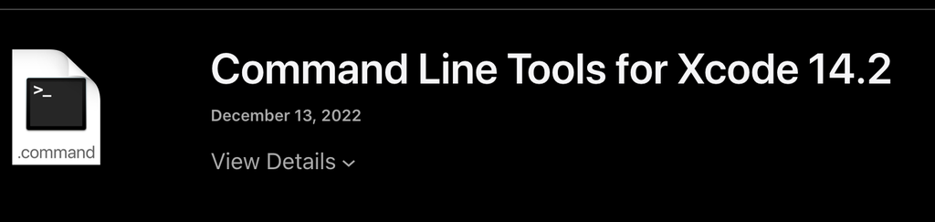

   - If this doesn’t work, you can download the Xcode application off of the Apple Store. Make sure you block off some time for this, since Xcode takes a while to download.
3. Install homebrew by copying and pasting the following command into Terminal: `/bin/bash -c "$(curl -fsSL https://raw.githubusercontent.com/Homebrew/install/HEAD/install.sh)"`
   - To find the Terminal application, use command-space to open the search bar and searching “Terminal”.
4. Once homebrew is installed, copy and paste the following command into Terminal: `$ brew install git`
   - If this isn’t working, check out [this video](https://www.youtube.com/watch?v=SOjSNB7F2m4).

Windows users:

1. If you haven’t already, install [winget](https://learn.microsoft.com/en-us/windows/package-manager/winget/).
2. Copy and paste the following command into Powershell or the command prompt: `winget install --id Git.Git -e --source winget`

**You can check whether git installation worked by opening RStudio and creating a new project. There should be an option to choose “Create a git repository”**

[figure not shown]

### Section 2: Linking git and GitHub

Generate a Personal Access Token (PAT):

1. If you haven’t already, create an account on [GitHub](https://github.com/).
2. Click on your account icon in the upper right-hand corner and go to Settings.
3. Scroll all the way down to Developer Settings on the left-hand side and select it.
4. Select Personal access tokens, then Tokens (classic).
5. Select Generate new token and then select the classic option.
6. Choose a name appropriate to your project as the token name.
7. Choose whichever expiration date is most suitable for your project.
8. Select the repo check box and make sure all of the boxes in that subsection are selected.
9. Click Generate token.
10. **Copy the token it generates and save it somewhere you can access it again. This is the only time you will have access to the token.**

Link RStudio to GitHub:

1. Install the credentials package by copying and pasting the following code into Console in RStudio: `install.packages("credentials")`
2. Run the following code in RStudio’s Terminal tab:

```r
git config --global user.email "put github email here"
git config --global user.name "put your name here"
credentials::set_github_pat("put PAT here")
```

- For any password that R or your computer asks of you, type your PAT.

### Section 3: Setting up a repository

Making a GitHub Repository:

1. Go to the GitHub homepage and on the left-hand side there should be a button to create your first or a new repository. Click it.
2. Name your repository according to your project.
3. Choose the Public option.
4. Check the box to add a README file.
5. Choose the MIT license, then click Create repository.

Linking the repository to GitHub:

1. Go to the repository. In the upper right-hand corner, click on the Code button.
2. Copy the link in the HTTPS box.

[figure not shown]

3. Go back to RStudio and in the upper right-hand corner, click the drop-down to create a new project.
4. Click the option called Version Control, then select Git.
5. Paste the link you just copied into the URL box, then copy the **exact** name of the repository into the box for the name of the directory.

[figure not shown]

Initial commits:

1. Go to the Terminal tab in RStudio and copy and paste the following commands:

```r
git add -A
git commit -am "short descriptive message here"
git push
```

2. Switch back to your GitHub repository on your web browser and reload the page. Your intial commits should appear.
3. You can type `git status` in the Terminal tab at any point to check the status of the synchrony between your local project and the GitHub workspace.

### Section 4: Setting up your first webpage

Enable pages in GitHub:

1. Go to your repository on GitHub and click the Settings tab.
2. On the left-hand side, scroll down and click the Pages icon.
3. For Source, choose Deploy from a branch, and choose main as the branch. Click Save.

Creating a homepage:

1. In RStudio, go to the upper left-hand side to create a new file. Choose an R Markdown file.
2. Name the file whatever you want the header to be, and make sure HTML is chosen for the format.
3. Click Knit, and a pop-up should show up to save your file. **Save your file as index.Rmd so that it will be your homepage.**
4. Create your homepage however you’d like and once you feel good, commit and push your changes as described above.
5. Access your new homepage at YourGithubUsername.github.io/YourRepositoryName/
6. Link new pages to your homepage using R Markdown files!

**All done!!**

[figure not shown]